# first run

```r
library(dplyr)
library(magrittr)
library(ggplot2)
library(tximport)
library(biomaRt)
library(DESeq2)

knitr::opts_chunk$set(cache = TRUE)
options(stringsAsFactors = FALSE)
```

## importing data

Using the ZIKA dataset that I am testing out IsoEM2 with, symlinked into this directory.

I already ran kallisto on the data, in `kallisto-allrna`, so I can jump right in at the stage of `tximport`

In order to import the data with the correct transcript and gene information, I can download it from biomart

```r
mart <- useMart("ensembl", dataset = "hsapiens_gene_ensembl")

transcript2gene <- getBM(attributes = c("ensembl_transcript_id", "ensembl_gene_id"), mart = mart) %>%
  # sorting
  arrange(ensembl_gene_id)
```

```r
kallistodirs <- Sys.glob("../data/kallisto-allrna/SRR*")
txi <- tximport(files=paste0(kallistodirs, "/abundance.h5"),
                type = "kallisto",
                tx2gene = transcript2gene,
                countsFromAbundance = "scaledTPM", ignoreTxVersion = TRUE)
```

```
## 1 2 3 4
## summarizing abundance
## summarizing counts
## summarizing length
```

Let’s grab the metadata too:

```r
# the Run col matches with what the folder names are
metadata <- read.delim("../data/SraRunTable.txt") %>% filter(Instrument == "Illumina MiSeq")
# making the appropriate factors
metadata$infection_status  %<>% gsub(pattern = " ", replacement = "", x = .) %>%  as.factor()
```

```r
# setting up row and column names for later, also to just keep track of things in the txi object
colnames(txi$counts) <- metadata$Run
rownames(metadata) <- metadata$Run
```

## making DESeq2 object

From this Bioconductor vignette: https://bioconductor.org/packages/release/bioc/vignettes/tximport/inst/doc/tximport.html#deseq2

```r
deseq <- DESeqDataSetFromTximport(txi, metadata, ~ infection_status)
```

```
## using just counts from tximport
```

filtering the object to remove rows that have 1 or less counts

```r
nrow(deseq)
```

```
## [1] 63456
```

```r
sum(rowSums(counts(deseq)) <=1)
```

```
## [1] 31325
```

```r
deseq <- deseq[rowSums(counts(deseq)) > 1, ]
nrow(deseq)
```

```
## [1] 32131
```

## Exploratory analysis

loading a package to look at mean sd plots

```r
library(vsn)
```

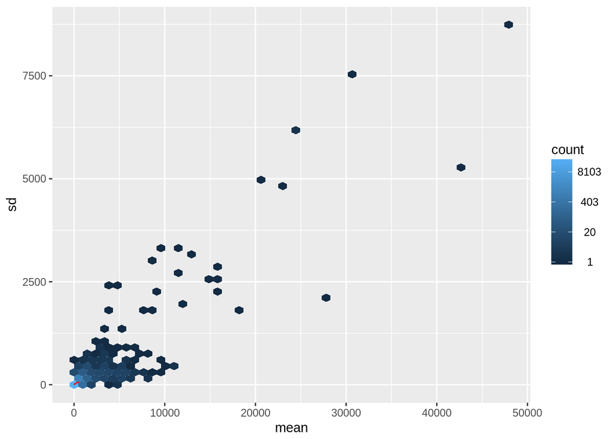

```r
meanSdPlot(counts(deseq), ranks = FALSE)
```

the next step is to do some corrections, they recommend doing an rlog transformation for small datasets, so I’ll stick with that.

```r
d.rlog <- rlog(deseq, blind = FALSE)
```

```
## -- note: fitType='parametric', but the dispersion trend was not well captured by the
##    function: y = a/x + b, and a local regression fit was automatically substituted.
##    specify fitType='local' or 'mean' to avoid this message next time.
```

and now the mean-sd plot:

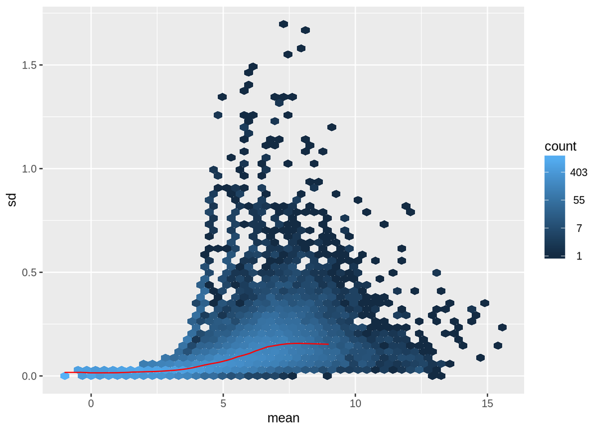

```r
meanSdPlot(assay(d.rlog), ranks = FALSE)
```

well, the goal is to have uniform variance at all means, and that doesn’t look like the case.

What about the other method?

```r
d.vst <- vst(deseq, blind = FALSE)
```

```
## -- note: fitType='parametric', but the dispersion trend was not well captured by the
##    function: y = a/x + b, and a local regression fit was automatically substituted.
##    specify fitType='local' or 'mean' to avoid this message next time.
```

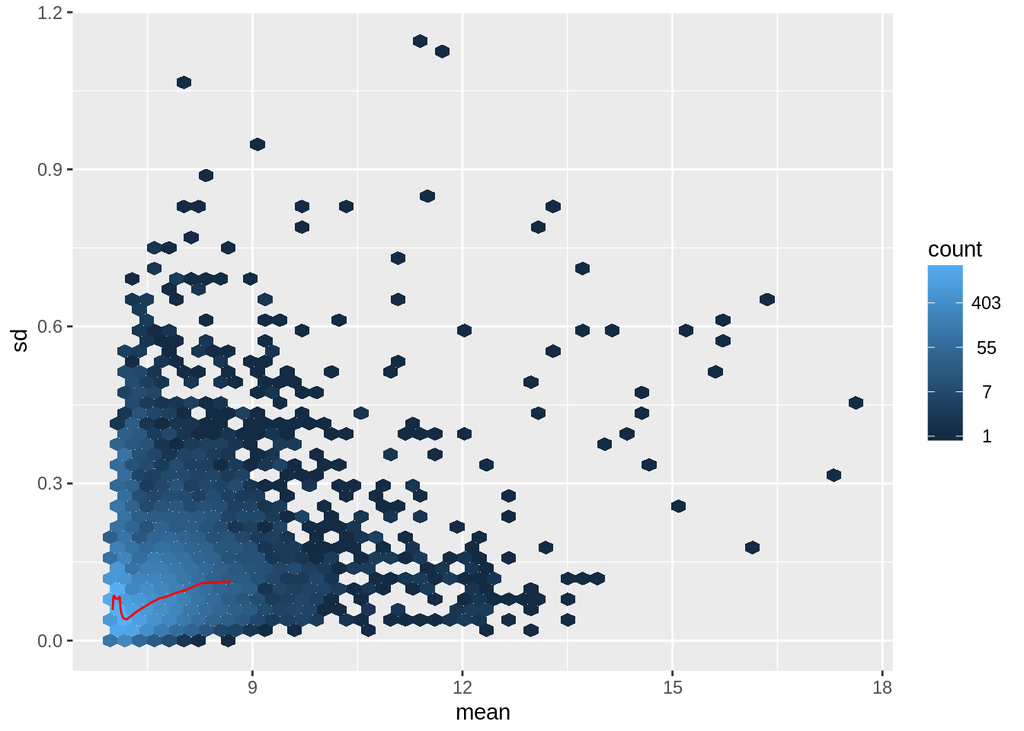

```r
meanSdPlot(assay(d.vst), ranks = FALSE)
```

Also trash.

Maybe this is because the kallisto input was already “scaled TPM”?

Reading up on the tximport / countsFromAbundance argument:

> character, either “no” (default), “scaledTPM”, or “lengthScaledTPM”, for whether to generate estimated counts using abundance estimates scaled up to library size (scaledTPM) or additionally scaled using the average transcript length over samples and the library size (lengthScaledTPM). if using scaledTPM or lengthScaledTPM, then the counts are no longer correlated with average transcript length, and so the length offset matrix should not be used.

ok, let’s try using the default of “no”, and getting the plot

```r
txi.d <- tximport(files=paste0(kallistodirs, "/abundance.h5"),
                type = "kallisto",
                tx2gene = transcript2gene, ignoreTxVersion = TRUE)
```

```
## 1 2 3 4
## summarizing abundance
## summarizing counts
## summarizing length
```

```r
dd <- DESeqDataSetFromTximport(txi.d, metadata, ~ infection_status)
```

```
## using counts and average transcript lengths from tximport
```

```r
nrow(dd)
```

```
## [1] 63456
```

```r
sum(rowSums(counts(dd)) <=1)
```

```
## [1] 35153
```

```r
dd <- dd[rowSums(counts(dd)) > 1, ]
nrow(dd)
```

```
## [1] 28303
```

```r
dd.rlog <- rlog(dd, blind = FALSE)
```

```
## using 'avgTxLength' from assays(dds), correcting for library size
```

```r
dd.vst <- vst(dd, blind = FALSE)
```

```
## using 'avgTxLength' from assays(dds), correcting for library size
```

hmm, looks promising that there was no garbage about fitting an lm, and instead it’s correcting for library size (the thing that the scaledTPM did already.)

plots

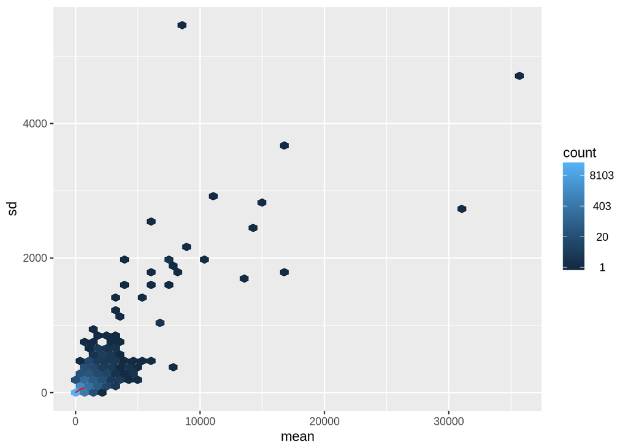

```r
meanSdPlot(counts(dd), ranks = FALSE)
```

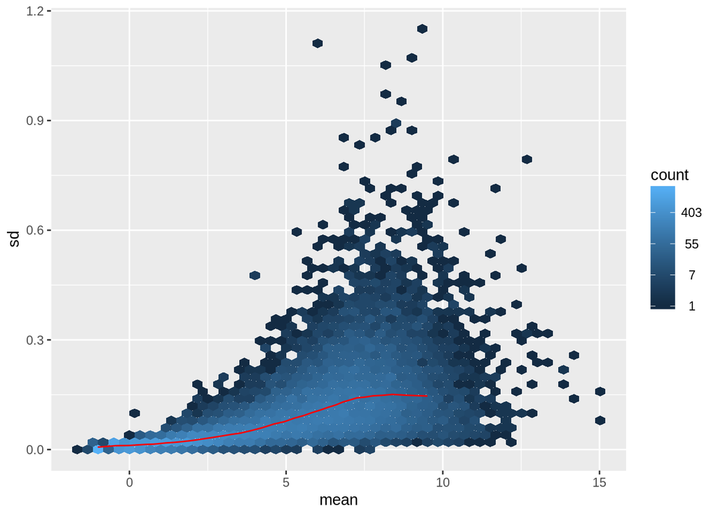

```r
meanSdPlot(assay(dd.rlog), ranks = FALSE)
```

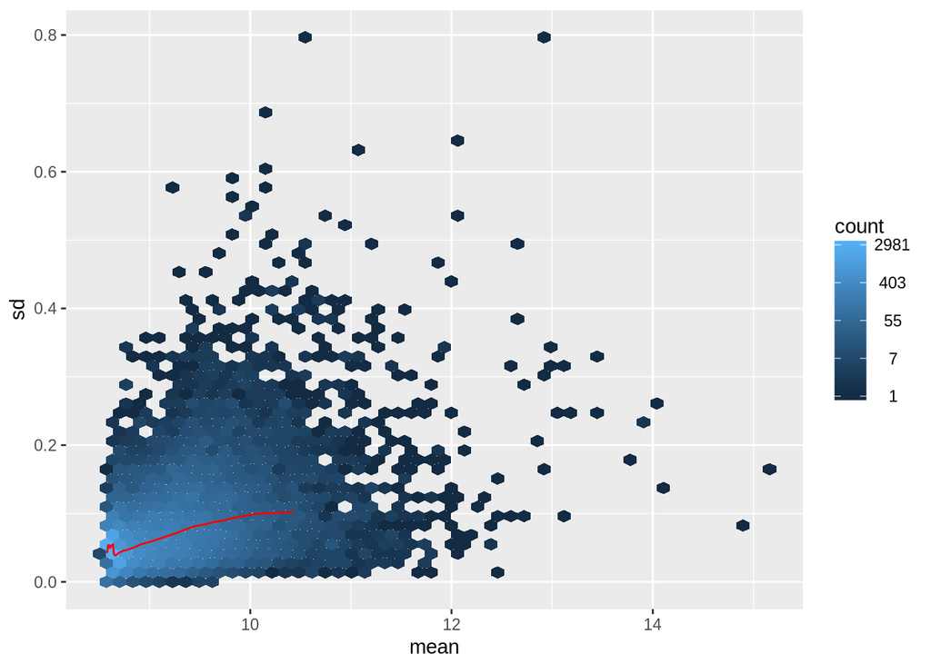

```r
meanSdPlot(assay(dd.vst), ranks = FALSE)
```

Still huge sprays of data. Doesn’t look like uniform sd at all.

But …. reading the workflow they mention using raw counts, so I guess I shouldn’t be using scaled TPM as input, and instead be reading in the raw counts from kallisto (*I’ll be using `dd` going forward*)